# Alexithymia Helper Glasses

## Intro

#### Alexithymia is a condition in which those who are diagnosed are unable to discern emotions in one's face. It is often called emotional blindness and it is a condition which affects many with depression, anxiety, and PTSD. Classification can be one solution to help those out with this situation. If we can get a model working in real time that updates what emotion someone is feeling it can help those with this condition have easier interactions with other people. For this I plan on using a random forest algorithm. We can also use opencv to help capture image in real time.

```python
import os
import cv2
import numpy as np
import pandas as pd
from sklearn.ensemble import RandomForestClassifier
from sklearn.model_selection import train_test_split
from sklearn.metrics import accuracy_score, classification_report

dataset_path = r"C:\Users\adith\Downloads\emotionDataset\train"

emotion_labels = ["angry", "happy", "sad", "neutral"]

X, y = [], []

for label_idx, emotion in enumerate(emotion_labels):
    emotion_folder = os.path.join(dataset_path, emotion)

    for img_name in os.listdir(emotion_folder):
        img_path = os.path.join(emotion_folder, img_name)

        img = cv2.imread(img_path, cv2.IMREAD_GRAYSCALE)

        img = cv2.resize(img, (48, 48))

        X.append(img.flatten())

        y.append(label_idx)

X = np.array(X) / 255.0
y = np.array(y)
```

## Data Understanding

#### To fully understand exactly how we are processing our images lets try to visualize exactly how we change our images to convert them into a usable format for our purposes.

```python
from PIL import Image
import numpy as np
image_path = r"C:\Users\adith\Downloads\test.jpg"
img = Image.open(image_path)
img2 = np.array(img)
print(img2)
```

```
[[193 199 202 ... 214 217 220]
 [194 200 203 ... 214 217 218]
 [193 198 201 ... 214 216 215]
 ...
 [167 172 186 ... 238 238 236]
 [168 172 184 ... 238 238 237]
 [172 173 180 ... 240 238 239]]
```

#### The numbers in the array represent the intensity of the color so exactly how dark or light it is. This makes it so we now have interpretible data for us to use when we train our model. The previous preprocessing steps were done so we could reduce the number of these values to make our process more computationally efficient

## Modeling

#### I've decided to use the random forest classifier for our purposes. The random forest classifier is an ensemble learning method so it uses multiple decision trees which will help reduce overfitting. It also automatically selects the most important features. Faces are often quite complex so random forest works well because it handles non linearity well. Random Forest also just reduces noise as it handles multiple decision trees. Random forest works by creating multiple decision trees off of different random parts of our dataset. Each tree makes their predicitions and the forest collects them and picks the most common answer which makes it more accurate and reliable.

```python
X_train, X_test, y_train, y_test = train_test_split(X, y, test_size=0.2, random_state=47, stratify=y)


rf_model = RandomForestClassifier(n_estimators=100, random_state=47)
rf_model.fit(X_train, y_train)


y_pred = rf_model.predict(X_test)



accuracy = accuracy_score(y_test, y_pred)
print(f"Accuracy: {accuracy:.2f}")


print(classification_report(y_test, y_pred, target_names=emotion_labels))
```

[output not shown]

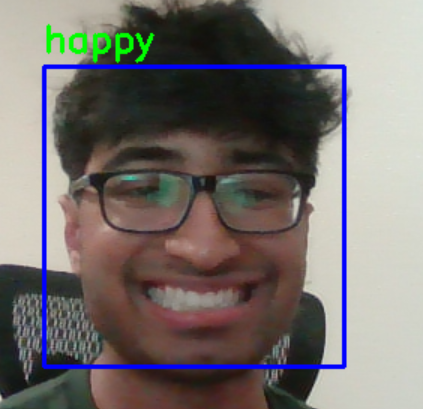

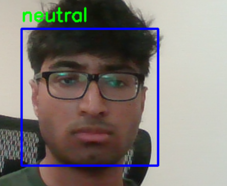

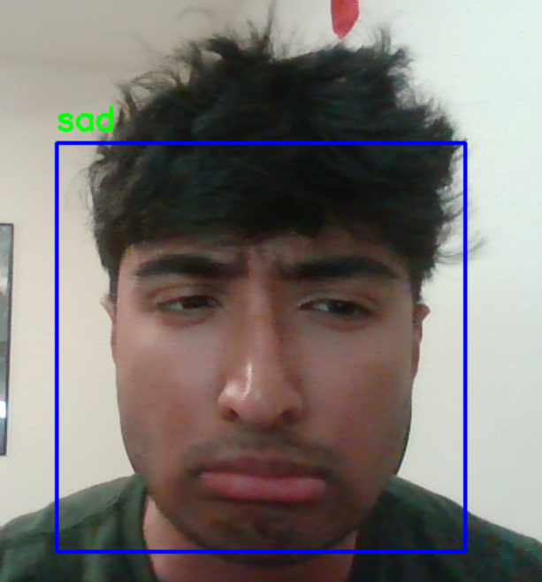

```python
from IPython.display import display
from PIL import Image

# Load and display the image
image_path = r"C:\Users\adith\OneDrive\Pictures\Screenshots\happytestProj2.png"
image_path2 = r"C:\Users\adith\OneDrive\Pictures\Screenshots\neutraltestProj2.png"
image_path3 = r"C:\Users\adith\OneDrive\Pictures\Screenshots\sadtestProj2.png"
img = Image.open(image_path)
img2 = Image.open(image_path2)
img3 = Image.open(image_path3)
display(img)
display(img2)
display(img3)
```

## Evaluation

#### After training my model has an accuracy of 0.51. For our metrics of measurement we are using Accuracy, Precision, recall, and F1-Score. Accuracy measures the proportion of correctly identified samples from our set. Accuracy is good as a general score but if our dataset is imbalanced it can be misleading. Recall mentions how many instances of a class were identified correctly. F1 Score ensures that there is a balance between precision and recall.

## Accuracy: 0.51

## Model Evaluation Metrics

### Accuracy: 0.51

### Class-wise Metrics:

| Class | Precision | Recall | F1-Score | Support |
| --- | --- | --- | --- | --- |
| Angry | 0.55 | 0.24 | 0.34 | 991 |
| Happy | 0.53 | 0.81 | 0.64 | 1798 |
| Sad | 0.45 | 0.39 | 0.41 | 1215 |
| Neutral | 0.52 | 0.43 | 0.47 | 1240 |

### Overall Metrics:

| Metric | Precision | Recall | F1-Score | Support |
| --- | --- | --- | --- | --- |
| **Macro Avg** | 0.51 | 0.47 | 0.47 | 5244 |
| **Weighted Avg** | 0.51 | 0.51 | 0.49 | 5244 |

## Impact

#### This project has many many potential impacts. If the model can be improved a little it can be used to help neurodivergent people and those with Alexithymia better identify emotions in other people and help improve the quality of their life. However, It could be used to by bad actors to identify emotions in interrogations or speechs and used as evidence to punish those for not complying with whatever they want. For example a dictator could survey the emotions of their populace while giving a speech. It would also need to be updated with many many more emotions and it might not be able to capture every nuance of emotion which might lead to bad situations for those using it.

## References

https://www.geeksforgeeks.org/insert-image-in-a-jupyter-notebook/

https://scikit-learn.org/stable/modules/generated/sklearn.ensemble.RandomForestClassifier.html

https://www.geeksforgeeks.org/opencv-python-tutorial/

## Github

https://github.com/AChakka/DataMiningProj2